# dog_app_inception

```python
from sklearn.datasets import load_files
import tensorflow
from keras.utils import np_utils
import numpy as np
from glob import glob

# define function to load train, test, and validation datasets
def load_dataset(path):
    data = load_files(path)
    dog_files = np.array(data['filenames'])
    dog_targets = np_utils.to_categorical(np.array(data['target']), 133)
    return dog_files, dog_targets

# load train, test, and validation datasets
train_files, train_targets = load_dataset('../../../data/dog_images/train')
valid_files, valid_targets = load_dataset('../../../data/dog_images/valid')
test_files, test_targets = load_dataset('../../../data/dog_images/test')

# load list of dog names
dog_names = [item[20:-1] for item in sorted(glob("../../../data/dog_images/train/*/"))]

# print statistics about the dataset
print('There are %d total dog categories.' % len(dog_names))
print('There are %s total dog images.\n' % len(np.hstack([train_files, valid_files, test_files])))
print('There are %d training dog images.' % len(train_files))
print('There are %d validation dog images.' % len(valid_files))
print('There are %d test dog images.'% len(test_files))
```

```
There are 133 total dog categories.
There are 8351 total dog images.

There are 6680 training dog images.
There are 835 validation dog images.
There are 836 test dog images.
```

```python
import random
random.seed(8675309)

# load filenames in shuffled human dataset
human_files = np.array(glob("../../../data/lfw/*/*"))
random.shuffle(human_files)

# print statistics about the dataset
print('There are %d total human images.' % len(human_files))
```

```
There are 13233 total human images.
```

```python
import cv2
import matplotlib.pyplot as plt
%matplotlib inline

# extract pre-trained face detector
face_cascade = cv2.CascadeClassifier('haarcascades/haarcascade_frontalface_alt.xml')
```

```python
# returns "True" if face is detected in image stored at img_path
def face_detector(img_path):
    img = cv2.imread(img_path)
    gray = cv2.cvtColor(img, cv2.COLOR_BGR2GRAY)
    faces = face_cascade.detectMultiScale(gray)
    return len(faces) > 0
```

```python
from keras.applications.resnet50 import ResNet50

# define ResNet50 model
ResNet50_model = ResNet50(weights='imagenet')
```

```
Downloading data from https://github.com/fchollet/deep-learning-models/releases/download/v0.2/resnet50_weights_tf_dim_ordering_tf_kernels.h5
```

```python
from keras.preprocessing import image
from tqdm import tqdm

def path_to_tensor(img_path):
    # loads RGB image as PIL.Image.Image type
    img = image.load_img(img_path, target_size=(224, 224))
    # convert PIL.Image.Image type to 3D tensor with shape (224, 224, 3)
    x = image.img_to_array(img)
    # convert 3D tensor to 4D tensor with shape (1, 224, 224, 3) and return 4D tensor
    return np.expand_dims(x, axis=0)

def paths_to_tensor(img_paths):
    list_of_tensors = [path_to_tensor(img_path) for img_path in tqdm(img_paths)]
    return np.vstack(list_of_tensors)
```

```python
from keras.applications.resnet50 import preprocess_input, decode_predictions

def ResNet50_predict_labels(img_path):
    # returns prediction vector for image located at img_path
    img = preprocess_input(path_to_tensor(img_path))
    return np.argmax(ResNet50_model.predict(img))
```

```python
### returns "True" if a dog is detected in the image stored at img_path
def dog_detector(img_path):
    prediction = ResNet50_predict_labels(img_path)
    return ((prediction <= 268) & (prediction >= 151))
```

```python
from PIL import ImageFile
ImageFile.LOAD_TRUNCATED_IMAGES = True

# pre-process the data for Keras
train_tensors = paths_to_tensor(train_files).astype('float32')
valid_tensors = paths_to_tensor(valid_files).astype('float32')
test_tensors = paths_to_tensor(test_files).astype('float32')
```

```python
import tensorflow

from keras.layers import Conv2D, MaxPooling2D, GlobalAveragePooling2D
from keras.layers import Dropout, Flatten, Dense
from keras.models import Sequential
```

```python
# prepare data augmentation configuration
epochs = 10
batch_size = 16
img_height, img_width = 224, 224
num_training, num_validation, num_testing = 6680, 835, 836
train_dir = '../../../data/dog_images/train/'
valid_dir = '../../../data/dog_images/valid/'
test_dir =  '../../../data/dog_images/test/'

train_datagen = image.ImageDataGenerator(
        rescale=1./255,
        rotation_range = 40,
        shear_range=0.2,
        zoom_range=0.2,
        horizontal_flip=True)
valid_datagen = image.ImageDataGenerator(rescale = 1./255)
test_datagen =  image.ImageDataGenerator(rescale = 1./255)

train_generator = train_datagen.flow_from_directory(train_dir, target_size=(img_height, img_width),
                                                    batch_size=batch_size, class_mode='categorical')

validation_generator = valid_datagen.flow_from_directory(valid_dir, target_size=(img_height, img_width),
    batch_size=batch_size, class_mode='categorical')

test_generator = test_datagen.flow_from_directory(
    test_dir, target_size = (img_height, img_width),
    batch_size = batch_size, class_mode = "categorical")
```

```
Found 6680 images belonging to 133 classes.
Found 835 images belonging to 133 classes.
Found 836 images belonging to 133 classes.
```

```python
### TODO: Obtain bottleneck features from another pre-trained CNN.
bottleneck_features = np.load('bottleneck_features/DogInceptionV3Data.npz')
train_bnf = bottleneck_features['train']
valid_bnf = bottleneck_features['valid']
test_bnf = bottleneck_features['test']
```

```python
### TODO: Define your architecture.

model = Sequential()
model.add(GlobalAveragePooling2D(input_shape=train_bnf.shape[1:]))
#model.add(Dense(256, activation = "relu"))
model.add(Dropout(0.50))
model.add(Dense(133, activation='softmax'))
model.summary()
```

```
_________________________________________________________________
Layer (type)                 Output Shape              Param #
=================================================================
global_average_pooling2d_1 ( (None, 2048)              0
_________________________________________________________________
dropout_1 (Dropout)          (None, 2048)              0
_________________________________________________________________
dense_1 (Dense)              (None, 133)               272517
=================================================================
Total params: 272,517
Trainable params: 272,517
Non-trainable params: 0
_________________________________________________________________
```

### (IMPLEMENTATION) Compile the Model

```python
### TODO: Compile the model.
model.compile(loss='categorical_crossentropy', optimizer='rmsprop', metrics=['accuracy'])
```

```python
### TODO: Train the model.
from keras.callbacks import ModelCheckpoint, EarlyStopping
checkpointer = ModelCheckpoint(filepath='saved_models/weights.best.InceptionV3.hdf5',
                               verbose=1, save_best_only=True)
earlypointer = EarlyStopping(monitor="val_loss", patience=10)
epoch = 200

history_resnet = model.fit(train_bnf, train_targets,
          validation_data=(valid_bnf, valid_targets),
          epochs=epoch, batch_size=20, callbacks=[checkpointer, earlypointer], verbose=1)
```

```
Train on 6680 samples, validate on 835 samples
```

### (IMPLEMENTATION) Load the Model with the Best Validation Loss

```python
### TODO: Load the model weights with the best validation loss.
model.load_weights('saved_models/weights.best.InceptionV3.hdf5')
```

### (IMPLEMENTATION) Test the Model

Try out your model on the test dataset of dog images. Ensure that your test accuracy is greater than 60%.

```python
### TODO: Calculate classification accuracy on the test dataset.
# get index of predicted dog breed for each image in test set
predictions = [np.argmax(model.predict(np.expand_dims(feature, axis=0))) for feature in test_bnf]

# report test accuracy
test_accuracy = 100*np.sum(np.array(predictions)==np.argmax(test_targets, axis=1))/len(predictions)
print('Test accuracy: %.4f%%' % test_accuracy)
model.save("saved_models/InceptionV3.hdf5")
```

```
Test accuracy: 78.8278%
```

```python
### TODO: Write a function that takes a path to an image as input
### and returns the dog breed that is predicted by the model.
#get the list of dog breeds
import re
regex = r"^.*/\d{3}\.(.*)$"

stripped_names = [re.sub(regex,r"\1",text ) for text in dog_names]
stripped_names = [re.sub(r"_", r" ", text) for text in stripped_names]
```

```python
dog_names = stripped_names
np.save('dog_names.npy',dog_names)
```

```python
#def predict_breed(img_path):

from extract_bottleneck_features import *

def inception_predict_breed(img_path):
    # extract bottleneck features
    bottleneck_feature = extract_InceptionV3(path_to_tensor(img_path))
    # obtain predicted vector
    predicted_vector = model.predict(bottleneck_feature)
    # return dog breed that is predicted by the model
    return stripped_names[np.argmax(predicted_vector)]
```

```python
tmp = path_to_tensor(test_files[1])
bf = extract_Resnet50(tmp)
bf.shape
```

```
Downloading data from https://github.com/fchollet/deep-learning-models/releases/download/v0.2/resnet50_weights_tf_dim_ordering_tf_kernels_notop.h5
```

```
(1, 1, 1, 2048)
```

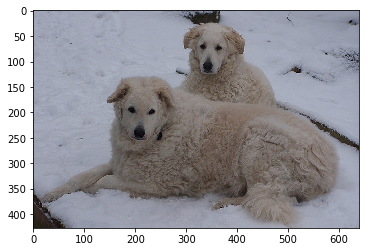

```
Downloading data from https://github.com/fchollet/deep-learning-models/releases/download/v0.5/inception_v3_weights_tf_dim_ordering_tf_kernels_notop.h5
This is a Kuvasv. The model predict dog: Kuvasz
```

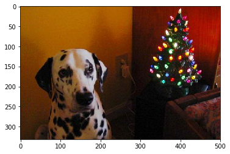

```
This is a Dalmation. The model predict dog: Dalmatian
```

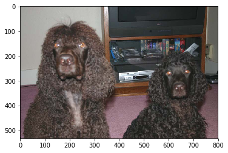

```
This is a Irish water spaniel. The model predict dog: Irish water spaniel
```

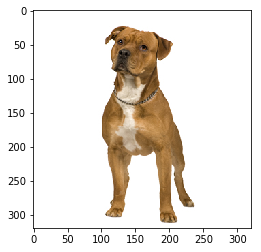

```
This is a American staffordshire terrier. The model predict dog: American staffordshire terrier
```

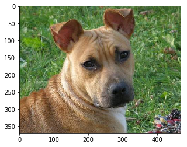

```
This is a American staffordshire terrier. The model predict dog: American staffordshire terrier
```

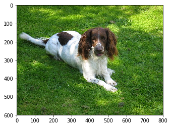

```
This is a English springer spaniel. The model predict dog: Irish red and white setter
```

```python
first_six = ["Kuvasv", "Dalmation","Irish water spaniel","American staffordshire terrier",
             "American staffordshire terrier", "English springer spaniel"]

for i in range(6):
    # load color (BGR) image
    cv_img = cv2.imread(train_files[i])
    # convert BGR image to RGB for plotting
    cv_img = cv2.cvtColor(cv_img, cv2.COLOR_BGR2RGB)

    # display the image, along with bounding box
    plt.imshow(cv_img)
    plt.show()
    print(f"This is a {first_six[i]}. The model predict dog: {inception_predict_breed(train_files[i])}")
```

## Step 6: Write your Algorithm

Write an algorithm that accepts a file path to an image and first determines whether the image contains a human, dog, or neither. Then,

- if a **dog** is detected in the image, return the predicted breed.
- if a **human** is detected in the image, return the resembling dog breed.
- if **neither** is detected in the image, provide output that indicates an error.

You are welcome to write your own functions for detecting humans and dogs in images, but feel free to use the `face_detector` and `dog_detector` functions developed above. You are **required** to use your CNN from Step 5 to predict dog breed.

A sample image and output for our algorithm is provided below, but feel free to design your own user experience!

[figure not shown]

This photo looks like an Afghan Hound.

### (IMPLEMENTATION) Write your Algorithm

```python
### TODO: Write your algorithm.
### Feel free to use as many code cells as needed.
def my_algo(img_path):
    if dog_detector(img_path):
        breed =  inception_predict_breed(img_path)
        # predict dog breed
        print(f"Hello dog! Your predicted dog breed is {breed}")

    elif face_detector(img_path):
        # predict dog breed
        breed =  inception_predict_breed(img_path)
        # predict dog breed
        print(f"Hello human! Your predicted dog breed is {breed}")

    else:
        print(f"Hello ??? I don't know what you are.")
```

## Step 7: Test Your Algorithm

In this section, you will take your new algorithm for a spin! What kind of dog does the algorithm think that **you** look like? If you have a dog, does it predict your dog's breed accurately? If you have a cat, does it mistakenly think that your cat is a dog?

### (IMPLEMENTATION) Test Your Algorithm on Sample Images!

Test your algorithm at least six images on your computer. Feel free to use any images you like. Use at least two human and two dog images.

**Question 6:** Is the output better than you expected :) ? Or worse :( ? Provide at least three possible points of improvement for your algorithm.

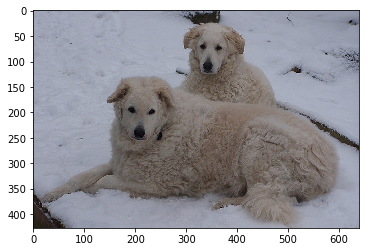

```
Hello dog! Your predicted dog breed is Kuvasz
```

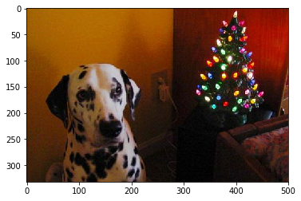

```
Hello dog! Your predicted dog breed is Dalmatian
```

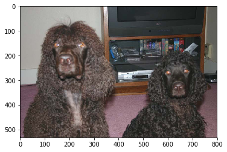

```
Hello dog! Your predicted dog breed is Irish water spaniel
```

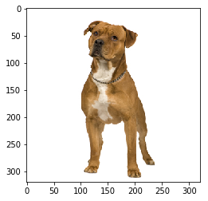

```
Hello dog! Your predicted dog breed is American staffordshire terrier
```

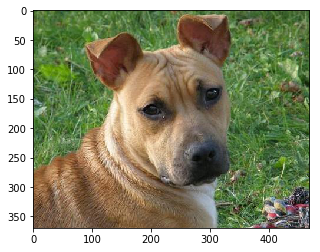

```
Hello dog! Your predicted dog breed is American staffordshire terrier
```

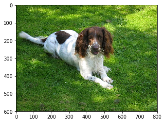

```
Hello dog! Your predicted dog breed is Irish red and white setter
```

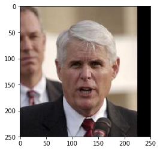

```
Hello human! Your predicted dog breed is Entlebucher mountain dog
```

[figure not shown]

```
Hello human! Your predicted dog breed is Bearded collie
```

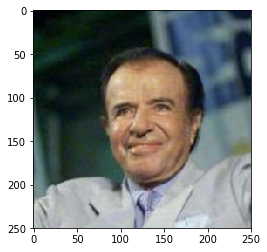

```
Hello human! Your predicted dog breed is Parson russell terrier
```

[figure not shown]

```
Hello human! Your predicted dog breed is Akita
```

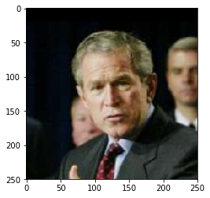

```
Hello human! Your predicted dog breed is Bearded collie
```

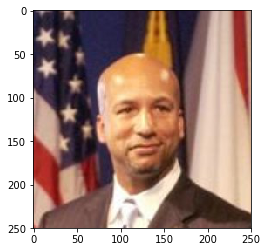

```
Hello human! Your predicted dog breed is Cocker spaniel
```

```python
## The algorithm is implemented using the first six images from the training set
first_six_dogs = ["Kuvasv", "Dalmation","Irish water spaniel","American staffordshire terrier",
             "American staffordshire terrier", "English springer spaniel"]

for i in range(6):
    # load color (BGR) image
    cv_img = cv2.imread(train_files[i])
    # convert BGR image to RGB for plotting
    cv_img = cv2.cvtColor(cv_img, cv2.COLOR_BGR2RGB)

    # display the image, along with bounding box
    plt.imshow(cv_img)
    plt.show()
    my_algo(train_files[i])

# The algorithm is implemented using the first six images in the humans data set
for i in range(6):
    # load color (BGR) image
    cv_img = cv2.imread(human_files[i])
    # convert BGR image to RGB for plotting
    cv_img = cv2.cvtColor(cv_img, cv2.COLOR_BGR2RGB)

    # display the image, along with bounding box
    plt.imshow(cv_img)
    plt.show()
    my_algo(human_files[i])
```